# MScA, Bayesian Methods (32014) Week 6 Workshop

Y. Balasanov, M.Tselishchev, © iLykei 2016

**References**

[G] Andrew Gelman, John B. Carlin, Hal S. Stern, David B. Dunson, Aki Vehtari, Donald B. Rubin, Bayesian Data Analysis, Third Edition, 2013, Taylor & Francis Group.  
[K] John K. Kruschke, Doing Bayesian Data Analysis, A Tutorial with R, JAGS, and STAN, 2015, Elsevier.

# 1 Fitting normal model for 1 group with no predictors

This example is based on [K], Chapter 16.

Prepare the data.

```r
# preparing data
set.seed(9384756)
y <- rnorm(100, mean = 6, sd = 3)
Ntotal = length(y)
```

```r
  dataList = list(
    y = y ,
    Ntotal = Ntotal ,
    mean_mu = mean(y) ,
    sd_mu = sd(y)
  )
```

For calculation of HDI use `hdi()` from `HDInterval`.

```r
library(HDInterval)
#source(paste(dataPath,"DBDA2E-utilities.R",sep="/"))
```

## 1.1 Running in JAGS

Specify the model.

```r
library(rjags)
```

(Do it Yourself)

```r
  modelString = "
  model {
    for ( i in 1:Ntotal ) {
      y[i] ~ dnorm( mu , 1/sigma^2 )
    }
    mu ~ dnorm(mean_mu , 1/(100*sd_mu)^2)
    sigma ~ dunif( sd_mu/1000 , sd_mu*1000 )
  }
  " # close quote for modelString
  # Write out modelString to a text file
  writeLines( modelString , con="TEMPmodel.txt" )
```

Initialize chains.

```r
  initsList <-function() {
    upDown<-sample(c(1,-1),1)
    m <- mean(y)*(1+upDown*.05)
    s <- sd(y)*(1-upDown*.1)
    list( mu = m , sigma = s)
  }
```

Run the chains.

```r
  parameters = c( "mu" , "sigma")     # The parameters to be monitored
  adaptSteps = 500               # Number of steps to "tune" the samplers
  burnInSteps = 1000
  numSavedSteps=50000
  nChains = 4
  thinSteps = 1
  nIter = ceiling( ( numSavedSteps * thinSteps ) / nChains )
    # Create, initialize, and adapt the model:
```

```r
  jagsModel = jags.model( "TEMPmodel.txt" , data=dataList , inits=initsList ,
                          n.chains=nChains , n.adapt=adaptSteps )
    # Burn-in:
    update( jagsModel , n.iter=burnInSteps )

    # Run it
    # The saved MCMC chain:
  codaSamples = coda.samples( jagsModel , variable.names=parameters ,
                              n.iter=nIter , thin=thinSteps )
```

Check how chains converged.

```r
summary(codaSamples)
```

```
##
## Iterations = 1501:14000
## Thinning interval = 1
## Number of chains = 4
## Sample size per chain = 12500
##
## 1. Empirical mean and standard deviation for each variable,
##    plus standard error of the mean:
##
##        Mean     SD Naive SE Time-series SE
## mu    6.457 0.3096 0.001385       0.001385
## sigma 3.102 0.2247 0.001005       0.001331
##
## 2. Quantiles for each variable:
##
##        2.5%   25%   50%   75% 97.5%
## mu    5.849 6.249 6.456 6.664 7.068
## sigma 2.702 2.945 3.089 3.243 3.584
```

The parameters are estimated close to what we simulated and very similar to what point estimation would give.

```r
mean(y)
```

```
## [1] 6.458036
```

```r
sd(y)
```

```
## [1] 3.063755
```

The plot of the samples and the densities of the parameters.

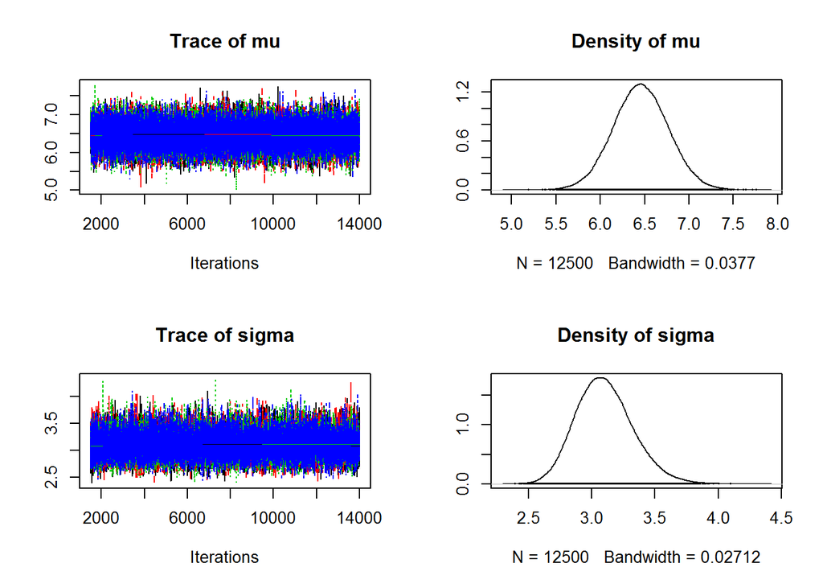

```r
plot(codaSamples)
```

The plot of autocorrelations.

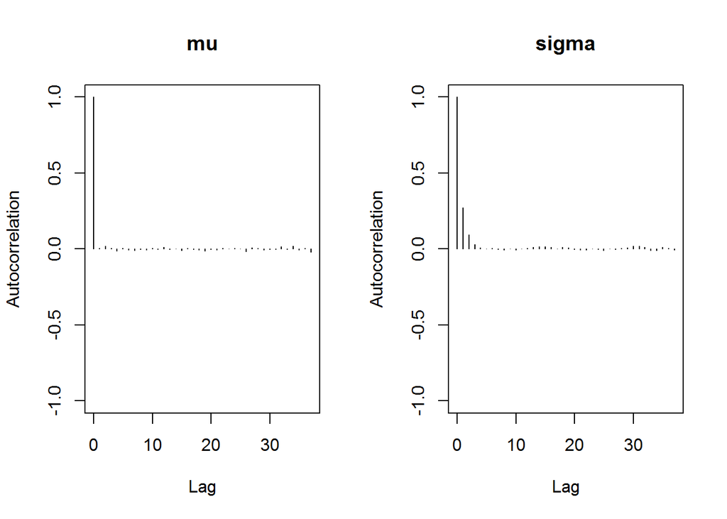

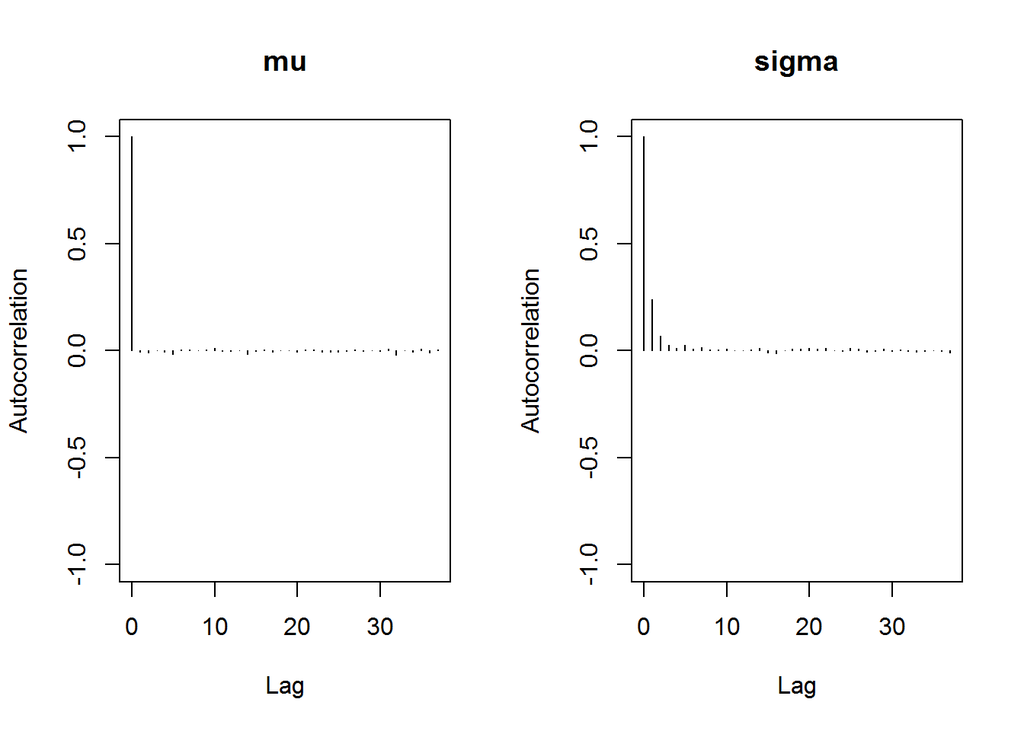

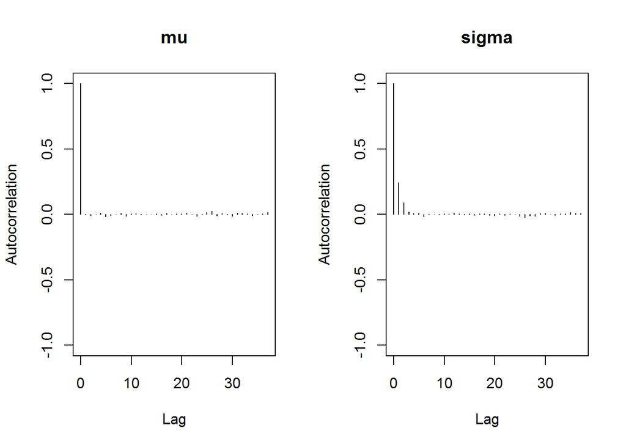

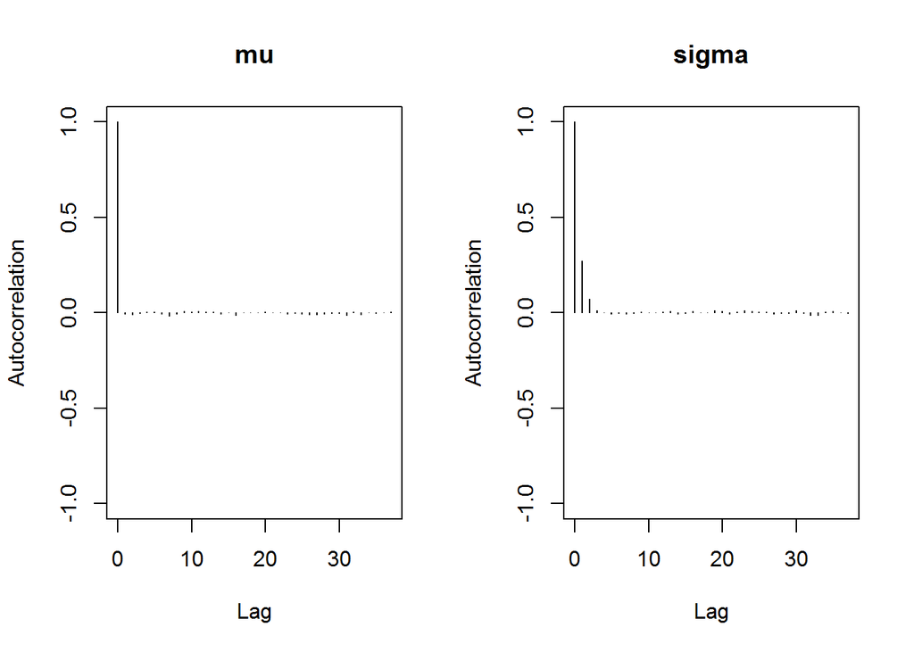

```r
autocorr.plot(codaSamples,ask=F)
```

Autocorrelation function plot shows that standard deviation effective size must be pretty small.  
Indeed:

```r
effectiveSize(codaSamples)
```

```
##       mu    sigma
## 50000.00 28520.96
```

Shrink factor shows that even with long memory for standard deviation distributions converged:

```r
gelman.diag(codaSamples)
```

```
## Potential scale reduction factors:
##
##       Point est. Upper C.I.
## mu             1          1
## sigma          1          1
##
## Multivariate psrf
##
## 1
```

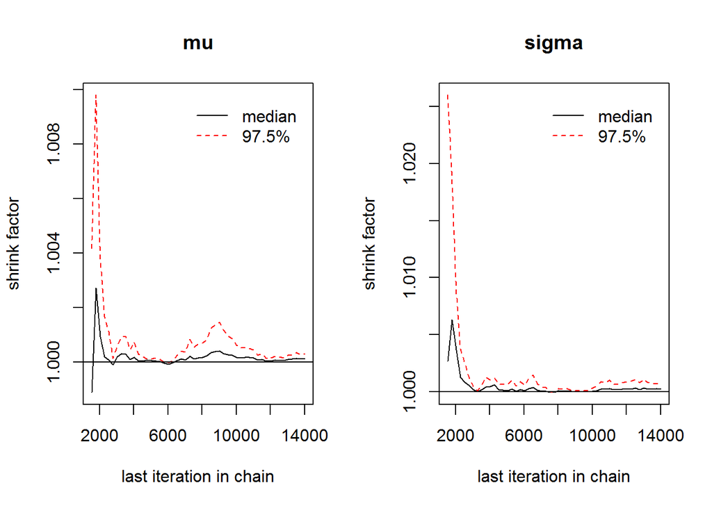

```r
gelman.plot(codaSamples)
```

Observed HDIs of the chains:

```r
lapply(codaSamples,function(z) hdi(as.matrix(z)))
```

```
## [[1]]
##             mu    sigma
## lower 5.845110 2.673674
## upper 7.045167 3.554842
## attr(,"credMass")
## [1] 0.95
##
## [[2]]
##             mu    sigma
## lower 5.859511 2.680711
## upper 7.087063 3.554076
## attr(,"credMass")
## [1] 0.95
##
## [[3]]
##             mu    sigma
## lower 5.851265 2.677556
## upper 7.085530 3.551092
## attr(,"credMass")
## [1] 0.95
##
## [[4]]
##             mu    sigma
## lower 5.846530 2.678862
## upper 7.053074 3.546948
## attr(,"credMass")
## [1] 0.95
```

## 1.2 Running in Stan

```r
library(rstan)
```

Use the description for Stan from file “ch16_1.stan” or write it yourself and compare with the code.

```r
modelString = "
data {
    int<lower=1> Ntotal;
    real y[Ntotal];
    real mean_mu;
    real sd_mu;
}
transformed data {
    real unifLo;
    real unifHi;
    real normalSigma;
    unifLo = sd_mu/100;
    unifHi = sd_mu*100;
    normalSigma = sd_mu*100;
}
parameters {
    real mu;
    real<lower=0> sigma;
}
model {
    sigma ~ uniform(unifLo, unifHi);
    mu ~ normal(mean_mu, normalSigma);
    y ~ normal(mu, sigma);
}
" # close quote for modelString
```

Create a DSO and save it to disk to reuse later or just keep it in memory.

```r
stanDso <- stan_model( model_code=modelString)
```

[output not shown]

If saved DSO is used load it, then run the chains.

```r
save(stanDso,file=paste(dataPath,"DSONormal1.Rds",sep="/"))
load(file=paste(dataPath,"DSONormal1.Rds",sep="/"))
```

```r
stanFit <- sampling( object=stanDso ,
                     data = dataList ,
                     pars=c('mu', 'sigma'),
                     chains = 2,
                     cores= 2,
                     iter = 5000,
                     warmup = 200,
                     thin = 1 )
```

Alternatively, use the description in “ch16_1.stan”.

```r
# fit model
fit <- stan (file=paste(dataPath,"ch16_1.stan",sep="/"),
             data=list(Ntotal=length(y),
                       y=y,
                       meanY=mean(y),
                       sdY=sd(y)),
             pars=c('mu', 'sigma'),
             #control=list(adapt_delta=0.99),
             iter=5000, chains = 2, cores = 2
             )
```

Objects `fit` and `stanFit` should return very similar results.  
The difference between `stan()` and `sampling()` is in the argument `object` which is DSO.  
If you expect to repeat same calculations with different data compiling a DSO and reusing it with `sampling()` is faster.

```r
# text statistics:
print (stanFit)
```

```
## Inference for Stan model: 0f0f371ff7610db18185e84127b50663.
## 2 chains, each with iter=5000; warmup=200; thin=1;
## post-warmup draws per chain=4800, total post-warmup draws=9600.
##
##          mean se_mean   sd    2.5%     25%     50%     75%   97.5% n_eff
## mu       6.46    0.00 0.32    5.85    6.25    6.46    6.67    7.08  9070
## sigma    3.11    0.00 0.23    2.70    2.95    3.10    3.25    3.60  4303
## lp__  -161.38    0.02 1.05 -164.26 -161.75 -161.06 -160.64 -160.37  3761
##       Rhat
## mu       1
## sigma    1
## lp__     1
##
## Samples were drawn using NUTS(diag_e) at Wed May 02 13:36:31 2018.
## For each parameter, n_eff is a crude measure of effective sample size,
## and Rhat is the potential scale reduction factor on split chains (at
## convergence, Rhat=1).
```

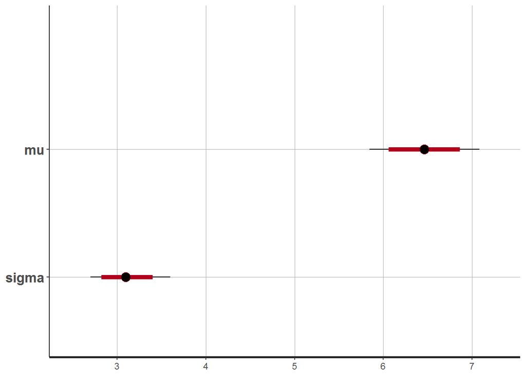

```r
# estimates & hdi:
plot(stanFit)
```

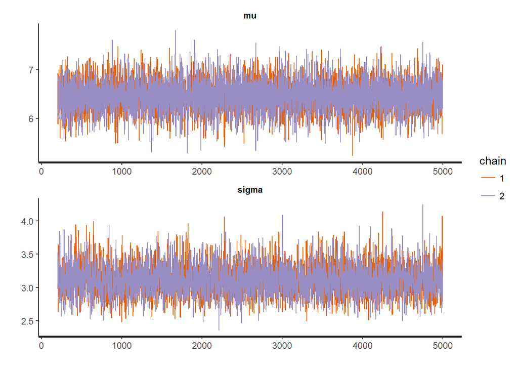

```r
# samples
traceplot(stanFit, ncol=1, inc_warmup=F)
```

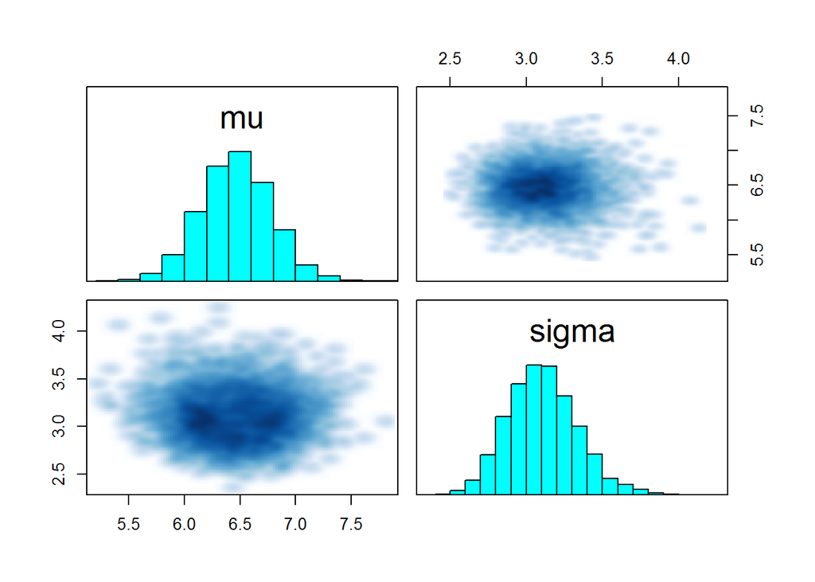

```r
pairs(stanFit, pars=c('mu','sigma'))
```

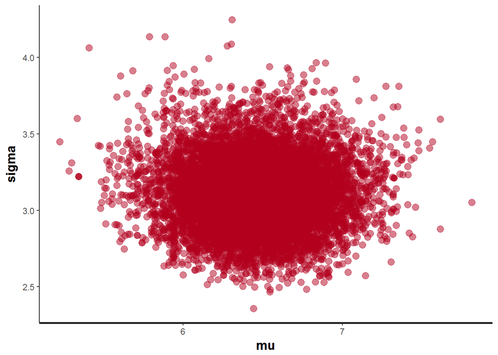

```r
stan_scat(stanFit, c('mu', 'sigma'))
```

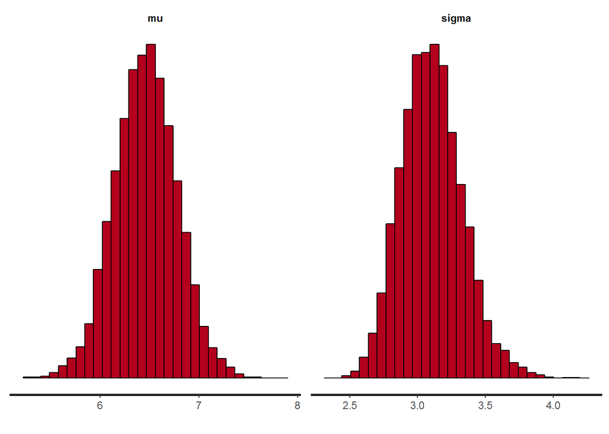

```r
stan_hist(stanFit)
```

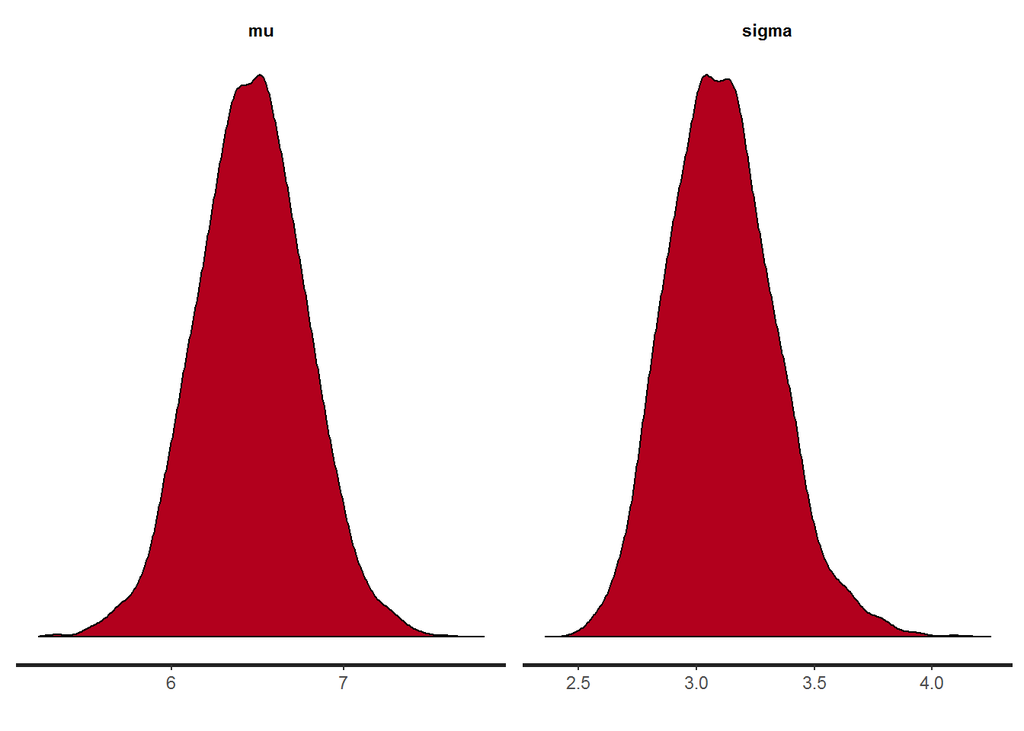

```r
stan_dens(stanFit)
```

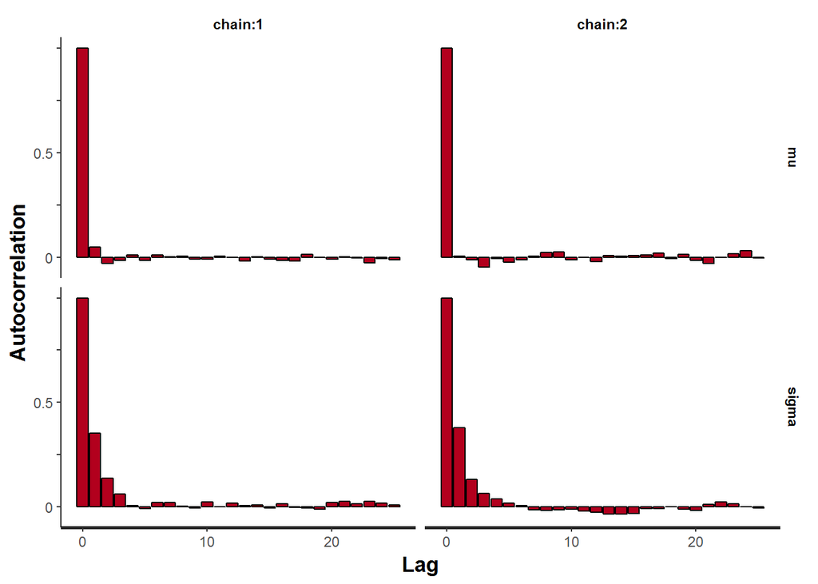

```r
# autocorrelation:
stan_ac(stanFit, separate_chains = T)
```

```r
# or you can work with familiar coda class:
library(coda)
stan2coda <- function(fit) {
    # apply to all chains
    mcmc.list(lapply(1:ncol(fit), function(x) mcmc(as.array(fit)[,x,])))
}
codaSamples <- stan2coda(stanFit)
summary(codaSamples)
```

```
##
## Iterations = 1:4800
## Thinning interval = 1
## Number of chains = 2
## Sample size per chain = 4800
##
## 1. Empirical mean and standard deviation for each variable,
##    plus standard error of the mean:
##
##           Mean     SD Naive SE Time-series SE
## mu       6.462 0.3156 0.003221       0.003176
## sigma    3.108 0.2278 0.002325       0.003415
## lp__  -161.382 1.0496 0.010712       0.016762
##
## 2. Quantiles for each variable:
##
##           2.5%      25%      50%      75%    97.5%
## mu       5.846    6.252    6.464    6.671    7.082
## sigma    2.698    2.947    3.097    3.254    3.599
## lp__  -164.257 -161.754 -161.062 -160.645 -160.374
```

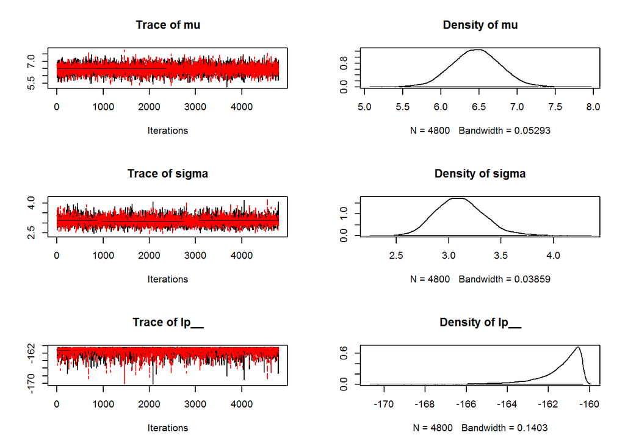

```r
plot(codaSamples)
```

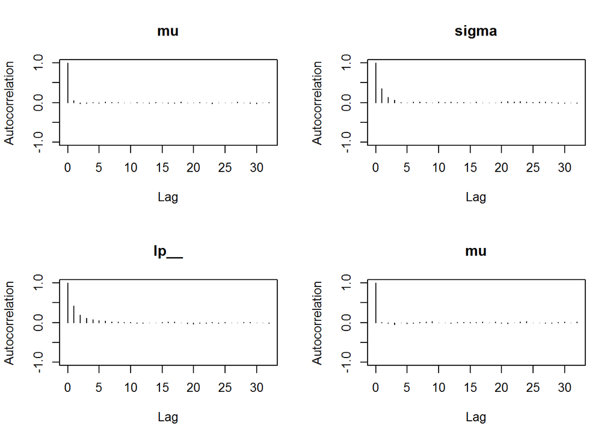

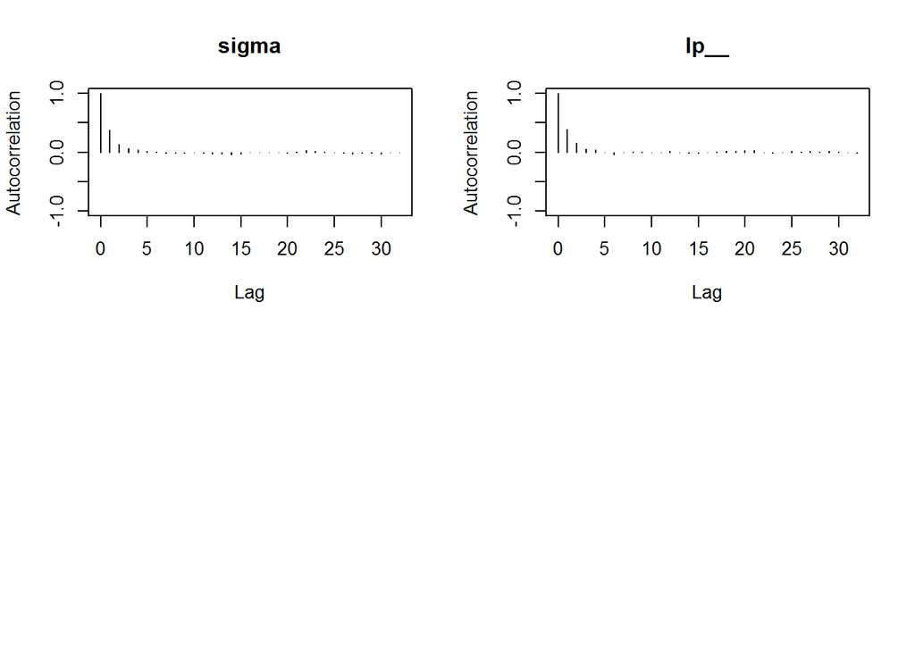

```r
autocorr.plot(codaSamples)
```

```r
effectiveSize(codaSamples)
```

```
##       mu    sigma     lp__
## 9910.265 4450.162 3961.376
```

```r
gelman.diag(codaSamples)
```

```
## Potential scale reduction factors:
##
##       Point est. Upper C.I.
## mu             1          1
## sigma          1          1
## lp__           1          1
##
## Multivariate psrf
##
## 1
```

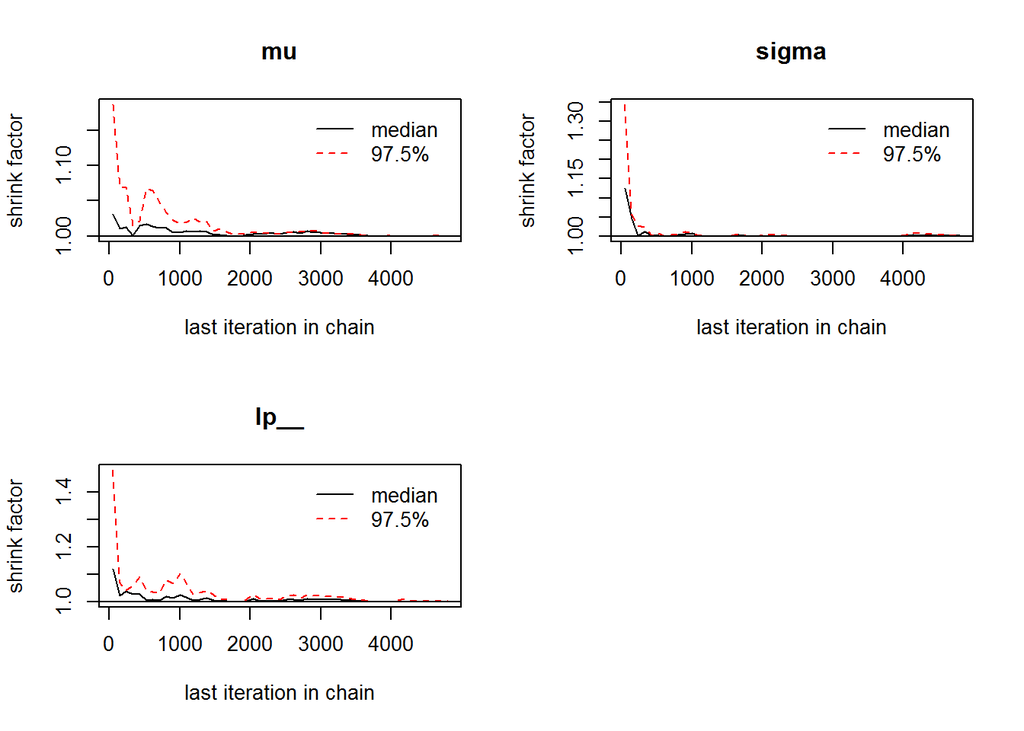

```r
gelman.plot(codaSamples)
```

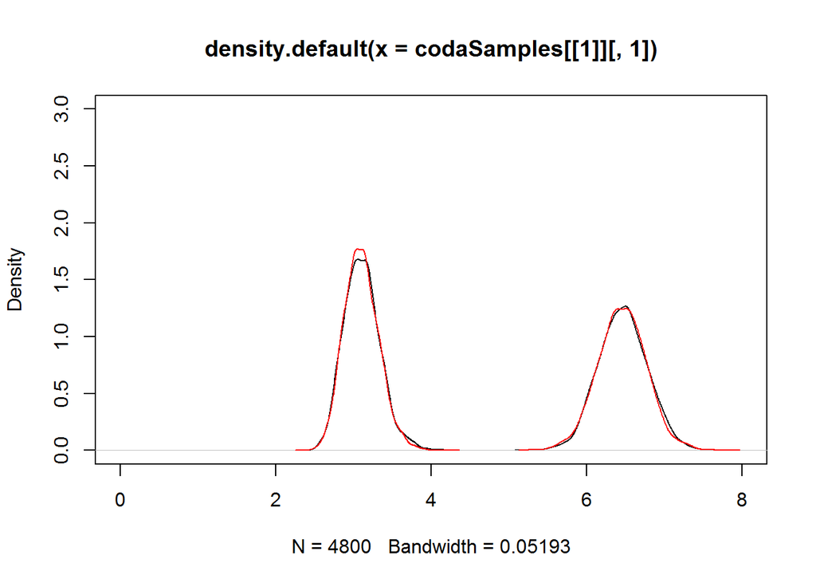

```r
plot(density(codaSamples[[1]][,1]),xlim=c(0,8),ylim=c(0,3))  # mu, 1st chain
lines(density(codaSamples[[1]][,2]))                         # sigma, 1st chain
lines(density(codaSamples[[2]][,1]),col="red")               # mu, 2nd chain
lines(density(codaSamples[[2]][,2]),col="red")               # sigma, 2nd chain
```

```r
# Or you can use shinystan to analyze fitted model
library(shinystan)
shinyFit<-as.shinystan(fit)
save(shinyFit,file=paste(dataPath,"shinyFit.Rdata",sep="/"))
launch_shinystan(fit)
```

# 2 Robust estimation using t-distribution

Create a sample with heavy tails in order to check robust estimation of parameters of normal distribution.  
You may remember this simulation of leprtokurtic distribution from Statistical Analysis (31007).

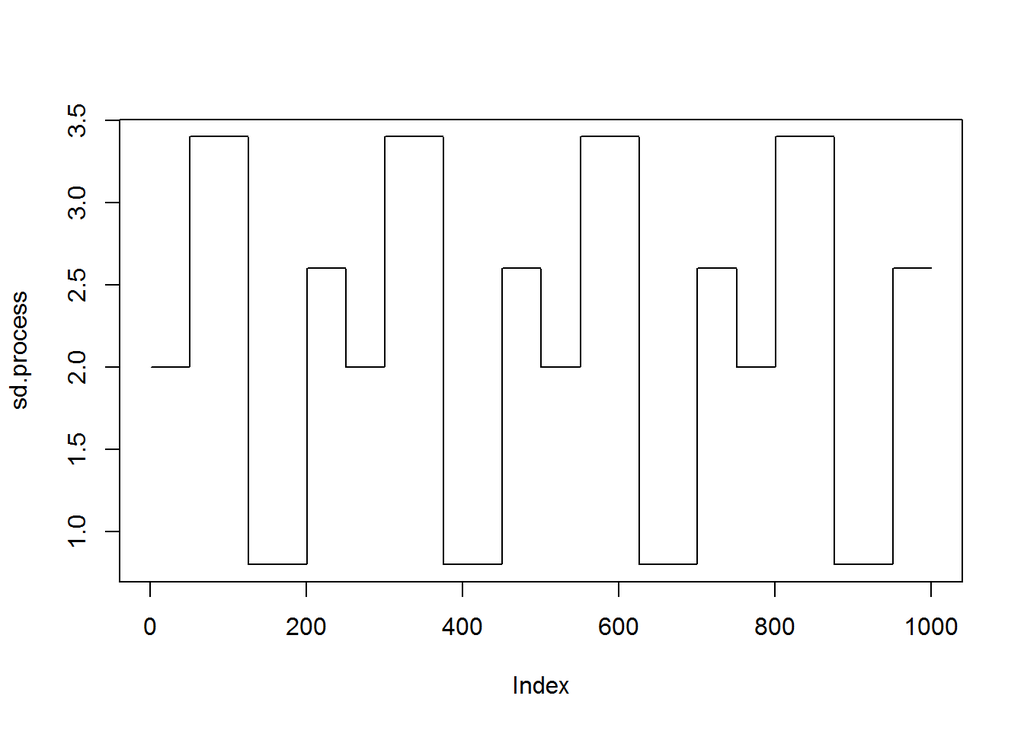

```r
nSample<-1000
sd.Values<-c(2,3.4,.8,2.6)
sd.process<-rep(c(rep(sd.Values[1],50),
                  rep(sd.Values[2],75),
                  rep(sd.Values[3],75),
                  rep(sd.Values[4],50)),
            4)

plot(sd.process,type="l")
```

Variable `sd.process` is a deterministically changing standard deviation.  
Simulating perfect normal and independent realizations with such different standard deviations make a leptokurtic distribution.

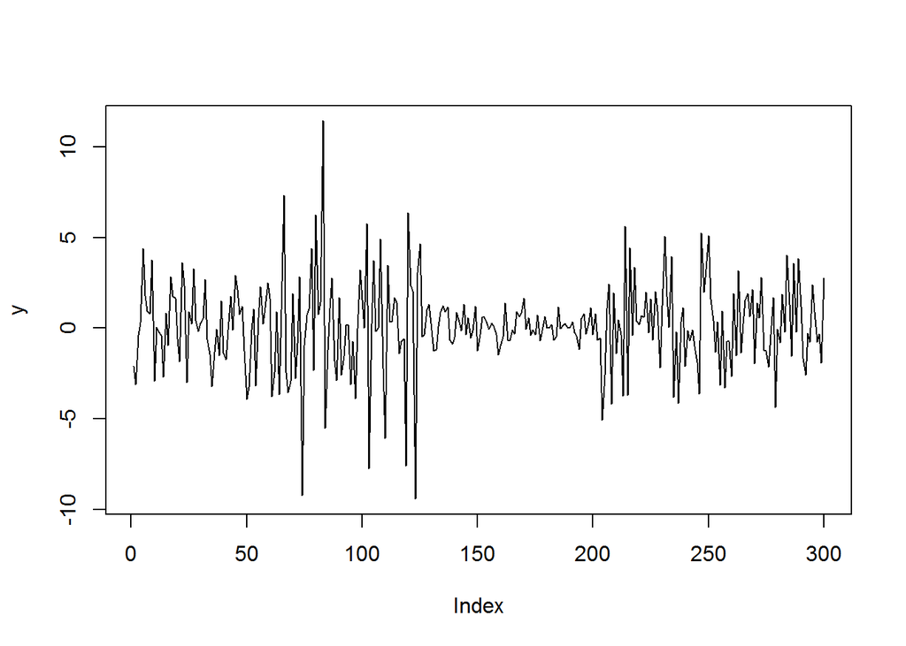

```r
set.seed(1112131415);
y<-rnorm(nSample)*sd.process
y<-y[1:300]
plot(y,type="l")
```

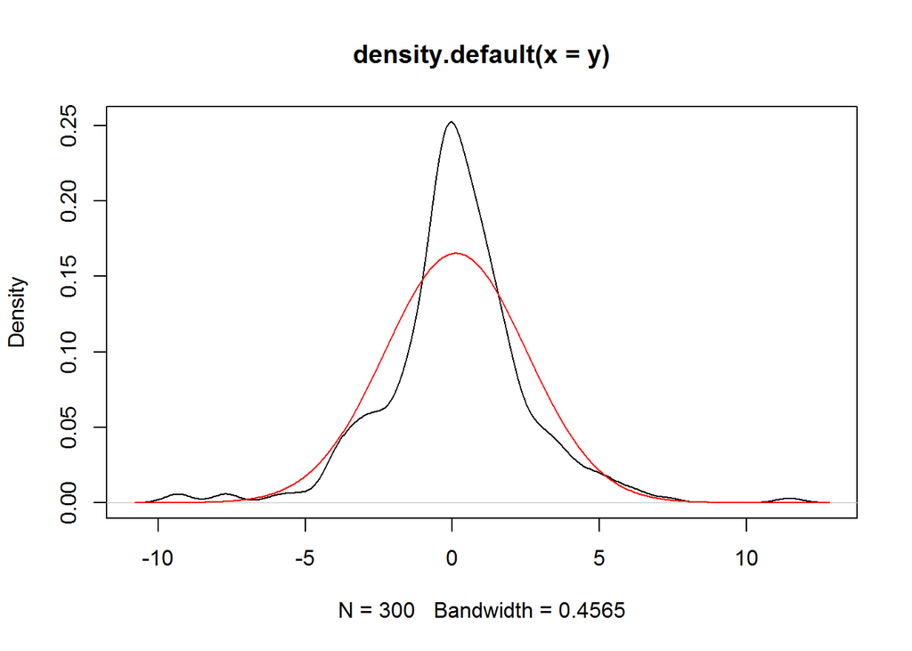

```r
den<-density(y)
plot(den)
lines(den$x,dnorm(den$x,mean(y),sd(y)),col="red")
```

```r
Ntotal = length(y)
```

Density plot clearly shows fat tails that will be most likely identified as outliers under the assumption of normal distribution.

Create data list.

```r
  dataList = list(
    y = y ,
    Ntotal = Ntotal ,
    mean_mu = mean(y) ,
    sd_mu = sd(y)
  )
```

## 2.1 JAGS

Describe the model in JAGS.

```r
modelString = "
model {
for ( i in 1:Ntotal ) {
    y[i] ~ dt(mu,1/sigma^2,nu)
}
mu ~ dnorm( mean_mu , 1/(100*sd_mu)^2 )
sigma ~ dunif( sd_mu/1000 , sd_mu*1000 )
nu ~ dexp(1/30.0)
}
  " # close quote for modelString
  # Write out modelString to a text file
writeLines( modelString , con="TEMPmodel.txt" )
```

Initialize the model with MLE.

```r
  initsList <-function() {
    upDown<-sample(c(1,-1),1)
    m <- mean(y)*(1+upDown*.05)
    s <- sd(y)*(1-upDown*.1)
    list( mu = m , sigma = s,nu=2)
  }
```

Transport the model to JAGS.

```r
parameters = c( "mu" , "sigma" , "nu" )     # The parameters to be monitored
adaptSteps = 500               # Number of steps to "tune" the samplers
burnInSteps = 1000
nChains = 3
thinSteps = 1
numSavedSteps=50000
(nIter = ceiling( ( numSavedSteps * thinSteps ) / nChains ))
```

```
## [1] 16667
```

```r
# Create, initialize, and adapt the model:
jagsModel = jags.model( "TEMPmodel.txt" , data=dataList , inits=initsList ,
                  n.chains=nChains , n.adapt=adaptSteps )
```

Run the chains.

```r
# Burn-in:
update( jagsModel , n.iter=burnInSteps )
# The saved MCMC chain:
codaSamples = coda.samples( jagsModel , variable.names=parameters ,
                      n.iter=nIter , thin=thinSteps )
```

Explore the results.

```r
summary(codaSamples)
```

```
##
## Iterations = 1501:18167
## Thinning interval = 1
## Number of chains = 3
## Sample size per chain = 16667
##
## 1. Empirical mean and standard deviation for each variable,
##    plus standard error of the mean:
##
##         Mean     SD  Naive SE Time-series SE
## mu    0.1346 0.1122 0.0005017      0.0006344
## nu    3.3832 0.9044 0.0040444      0.0109591
## sigma 1.6163 0.1415 0.0006330      0.0015723
##
## 2. Quantiles for each variable:
##
##           2.5%     25%    50%   75% 97.5%
## mu    -0.08554 0.05953 0.1346 0.210 0.354
## nu     2.12862 2.75714 3.2193 3.820 5.584
## sigma  1.35315 1.51763 1.6120 1.711 1.906
```

```r
mean(y)
```

```
## [1] 0.1121558
```

```r
sd(y)
```

```
## [1] 2.413726
```

Note that the robust estimate of $\mu$ is similar, but $\sigma$ is significantly smaller.

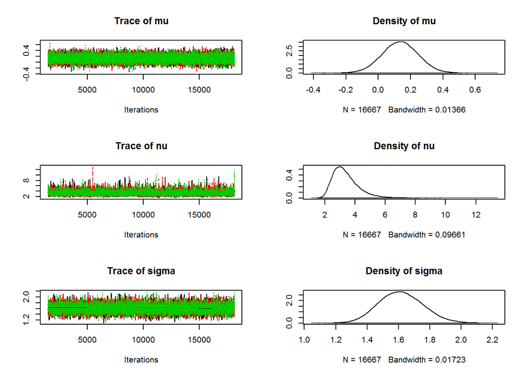

```r
plot(codaSamples)
```

```r
summary(sd.process)
```

```
##    Min. 1st Qu.  Median    Mean 3rd Qu.    Max.
##    0.80    0.80    2.30    2.18    3.40    3.40
```

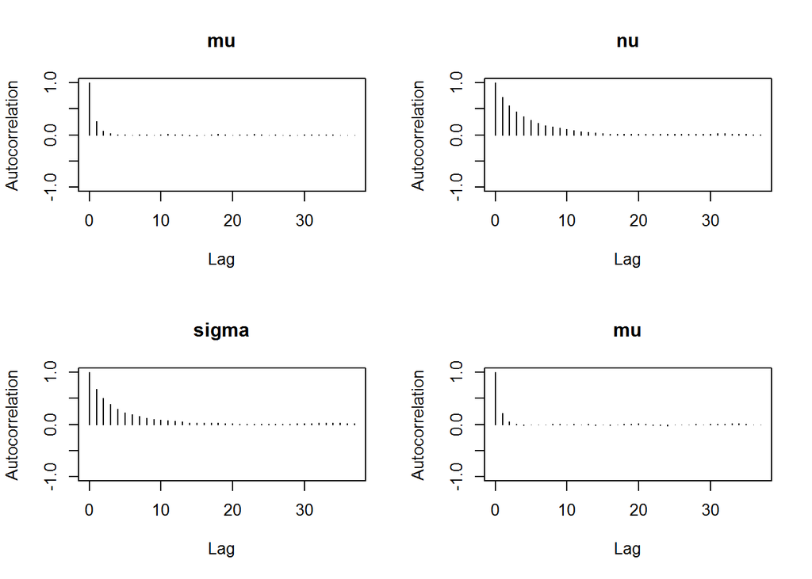

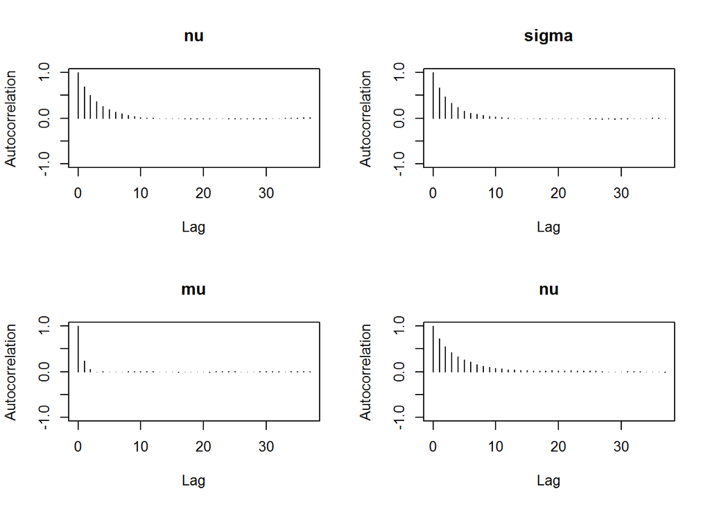

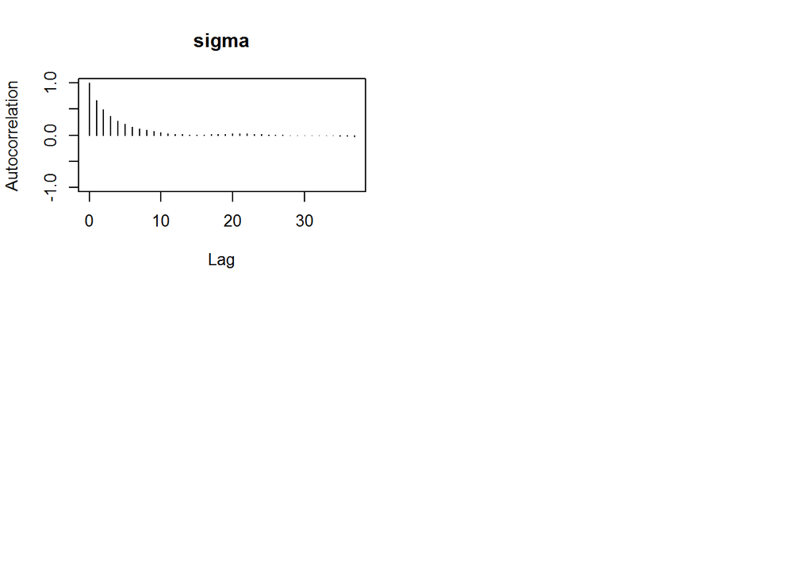

```r
autocorr.plot(codaSamples,ask=F)
```

```r
effectiveSize(codaSamples)
```

```
##        mu        nu     sigma
## 31313.528  6926.969  8151.475
```

Note that effective sizes for $\nu$ and $\sigma$ are quite small.  
We may need to run MCMC in Stan.

```r
gelman.diag(codaSamples)
```

```
## Potential scale reduction factors:
##
##       Point est. Upper C.I.
## mu             1          1
## nu             1          1
## sigma          1          1
##
## Multivariate psrf
##
## 1
```

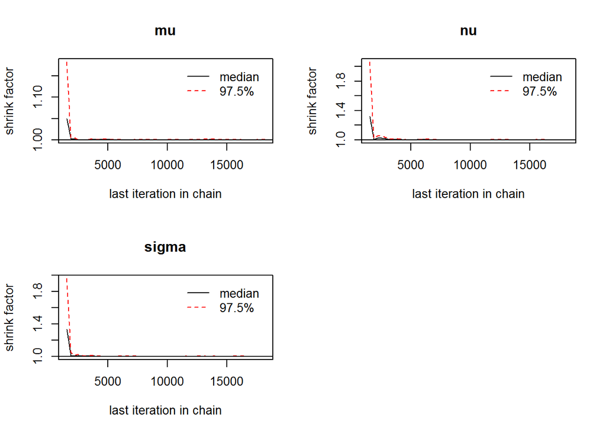

```r
gelman.plot(codaSamples)
```

```r
head(codaSamples[1])
```

```
## [[1]]
## Markov Chain Monte Carlo (MCMC) output:
## Start = 1501
## End = 1507
## Thinning interval = 1
##                mu       nu    sigma
## [1,] -0.005536036 3.730288 1.730913
## [2,]  0.132265497 2.613016 1.480249
## [3,] -0.028313189 2.366156 1.450023
## [4,]  0.206223989 2.312007 1.395967
## [5,]  0.119421836 2.299960 1.488853
## [6,]  0.029362476 2.301667 1.561244
## [7,] -0.103675170 2.209153 1.497068
##
## attr(,"class")
## [1] "mcmc.list"
```

```r
(HDIofChains<-lapply(codaSamples,function(z) hdi(as.matrix(z))))
```

```
## [[1]]
##               mu       nu    sigma
## lower -0.0839100 1.918168 1.340168
## upper  0.3568266 5.181386 1.900759
## attr(,"credMass")
## [1] 0.95
##
## [[2]]
##                mu       nu    sigma
## lower -0.08885163 1.942361 1.341442
## upper  0.35088476 5.173327 1.890880
## attr(,"credMass")
## [1] 0.95
##
## [[3]]
##               mu       nu    sigma
## lower -0.0830686 2.018669 1.347349
## upper  0.3523173 5.206704 1.887536
## attr(,"credMass")
## [1] 0.95
```

Non-robust estimate of $\sigma$ is outside the HDI for all the chains.

## 2.2 Stan

Adapt the model description to t-distribution with additional parameter $\nu$.

```r
modelString = "
data {
    int<lower=1> Ntotal;
    real y[Ntotal];
    real mean_mu;
    real sd_mu;
}
transformed data {
    real unifLo;
    real unifHi;
    real normalSigma;
    real expLambda;         //New: parameter of prior for nu
    unifLo = sd_mu/1000;
    unifHi = sd_mu*1000;
    normalSigma = sd_mu*100;
    expLambda=1/29.0;      //New: setting value for expLambda
}
parameters {
    real<lower=0> nuMinusOne; //New: definition of additional parameter nu
    real mu;
    real<lower=0> sigma;
}
transformed parameters {
    real<lower=0> nu;           //New: new parameter nu
    nu=nuMinusOne+1;           //New: shifting nu to avoid zero
}
model {
    sigma ~ uniform(unifLo, unifHi);
    mu ~ normal(mean_mu, normalSigma);
    nuMinusOne~exponential(expLambda);      //New: exponential prior for nu
    y ~ student_t(nu, mu, sigma);           //New: student_t distribution for nu
}
" # close quote for modelString
```

Create DSO.

Create DSO.

```r
stanDso <- stan_model( model_code=modelString )
```

[output not shown]

Save it if necessary.

```r
save(stanDso,file=paste(dataPath,"DSONormal2.Rds",sep="/"))
load(file=paste(dataPath,"DSONormal2.Rds",sep="/"))
```

Run MCMC.

```r
stanFitRobust <- sampling( object=stanDso ,
                     data = dataList ,
                     pars=c('nu','mu', 'sigma'),
                     chains = 3,
                     cores= 3,
                     iter = 50000,
                     warmup = 300,
                     thin = 1 )
```

Explore the results.

```r
# text statistics:
print (stanFitRobust)
```

```
## Inference for Stan model: e67fa4c368c01a78b59917da9be5f705.
## 3 chains, each with iter=50000; warmup=300; thin=1;
## post-warmup draws per chain=49700, total post-warmup draws=149100.
##
##          mean se_mean   sd    2.5%     25%     50%     75%   97.5% n_eff
## nu       3.39    0.00 0.89    2.13    2.77    3.23    3.82    5.56 79053
## mu       0.13    0.00 0.11   -0.08    0.06    0.13    0.21    0.36 95568
## sigma    1.62    0.00 0.14    1.36    1.52    1.61    1.71    1.90 78091
## lp__  -495.88    0.01 1.24 -499.10 -496.44 -495.56 -494.97 -494.46 57180
##       Rhat
## nu       1
## mu       1
## sigma    1
## lp__     1
##
## Samples were drawn using NUTS(diag_e) at Wed May 02 13:41:23 2018.
## For each parameter, n_eff is a crude measure of effective sample size,
## and Rhat is the potential scale reduction factor on split chains (at
## convergence, Rhat=1).
```

```
## ci_level: 0.8 (80% intervals)
```

```
## outer_level: 0.95 (95% intervals)
```

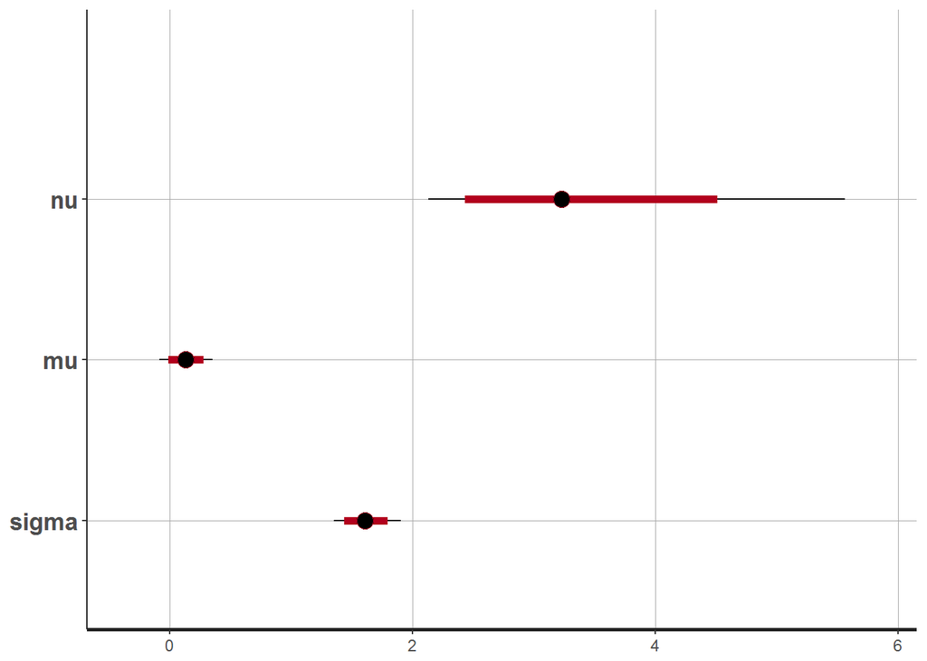

```r
# estimates & hdi:
plot(stanFitRobust)
```

```r
# samples
class(stanFitRobust)
```

```
## [1] "stanfit"
## attr(,"package")
## [1] "rstan"
```

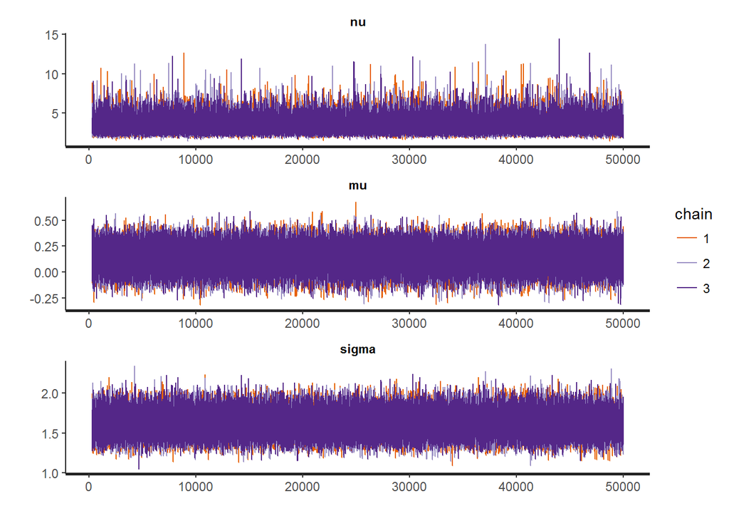

```r
rstan::traceplot(stanFitRobust, ncol=1, inc_warmup=F)
```

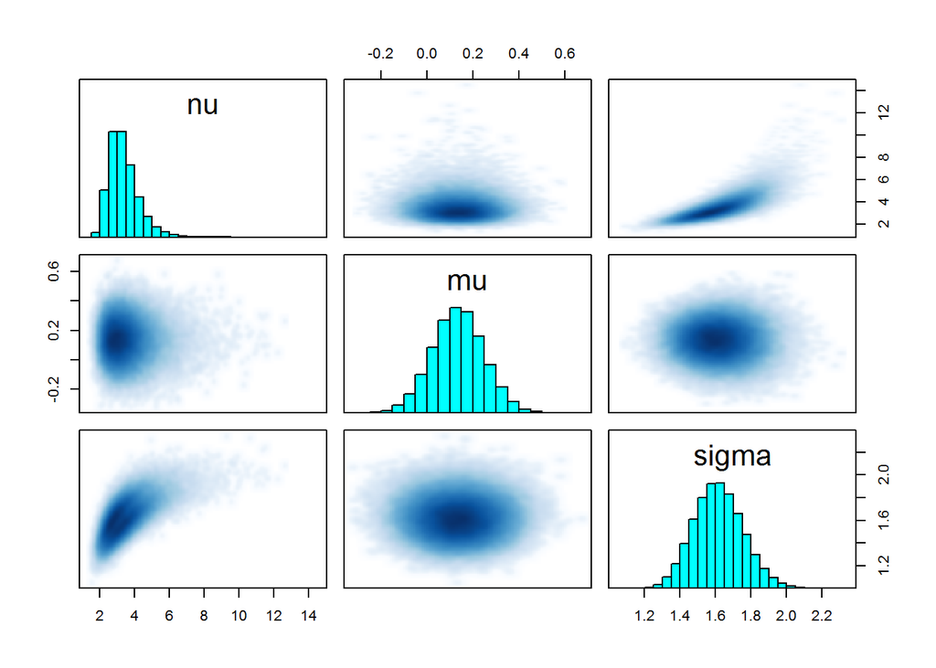

```r
pairs(stanFitRobust, pars=c('nu','mu','sigma'))
```